# Understanding Sales patterns and return dynamics in E-Commerce

Team 3

2024-11-16

# 1 Introduction

## 1.1 Source of the Dataset

## 1.2 SMART Framework Questions

## 1.3 Exploratory Data Analysis

## 1.4 Glimpse of a dataset

```r
data=read.csv("online_sales_dataset.csv")
head(data, 5)
```

```
##   InvoiceNo StockCode Description Quantity      InvoiceDate UnitPrice
## 1    221958  SKU_1964   White Mug       38 01-01-2020 00:00      1.71
## 2    771155  SKU_1241   White Mug       18 01-01-2020 01:00     41.25
## 3    231932  SKU_1501  Headphones       49 01-01-2020 02:00     29.11
## 4    465838  SKU_1760   Desk Lamp       14 01-01-2020 03:00     76.68
## 5    359178  SKU_1386   USB Cable      -30 01-01-2020 04:00    -68.11
##   CustomerID        Country Discount PaymentMethod ShippingCost    Category
## 1      37039      Australia 0.470000 Bank Transfer        10.79     Apparel
## 2      19144          Spain 0.190000       paypall         9.51 Electronics
## 3      50472        Germany 0.350000 Bank Transfer        23.03 Electronics
## 4      96586    Netherlands 0.140000       paypall        11.08 Accessories
## 5         NA United Kingdom 1.501433 Bank Transfer           NA Electronics
##   SalesChannel ReturnStatus ShipmentProvider WarehouseLocation OrderPriority
## 1     In-store Not Returned              UPS            London        Medium
## 2       Online Not Returned              UPS              Rome        Medium
## 3       Online     Returned              UPS            Berlin          High
## 4       Online Not Returned       Royal Mail              Rome           Low
## 5     In-store Not Returned            FedEx                          Medium
```

## 1.5 Structure and Summary of Dataset

```r
str(data)
```

```
## 'data.frame':    39432 obs. of  17 variables:
##  $ InvoiceNo        : int  221958 771155 231932 465838 359178 744167 210268 832180 154886 237337 ...
##  $ StockCode        : chr  "SKU_1964" "SKU_1241" "SKU_1501" "SKU_1760" ...
##  $ Description      : chr  "White Mug" "White Mug" "Headphones" "Desk Lamp" ...
##  $ Quantity         : int  38 18 49 14 -30 47 25 8 19 40 ...
##  $ InvoiceDate      : chr  "01-01-2020 00:00" "01-01-2020 01:00" "01-01-2020 02:00" "01-01-2020 03:00" ...
##  $ UnitPrice        : num  1.71 41.25 29.11 76.68 -68.11 ...
##  $ CustomerID       : int  37039 19144 50472 96586 NA 53887 46567 75098 87950 39718 ...
##  $ Country          : chr  "Australia" "Spain" "Germany" "Netherlands" ...
##  $ Discount         : num  0.47 0.19 0.35 0.14 1.5 ...
##  $ PaymentMethod    : chr  "Bank Transfer" "paypall" "Bank Transfer" "paypall" ...
##  $ ShippingCost     : num  10.79 9.51 23.03 11.08 NA ...
##  $ Category         : chr  "Apparel" "Electronics" "Electronics" "Accessories" ...
##  $ SalesChannel     : chr  "In-store" "Online" "Online" "Online" ...
##  $ ReturnStatus     : chr  "Not Returned" "Not Returned" "Returned" "Not Returned" ...
##  $ ShipmentProvider : chr  "UPS" "UPS" "UPS" "Royal Mail" ...
##  $ WarehouseLocation: chr  "London" "Rome" "Berlin" "Rome" ...
##  $ OrderPriority    : chr  "Medium" "Medium" "High" "Low" ...
```

```r
xkablesummary(data, title = "Summary of Dataset")
```

Summary of Dataset

|  | InvoiceNo | StockCode | Description | Quantity | InvoiceDate | UnitPrice | CustomerID | Country | Discount | PaymentMethod | ShippingCost | Category | SalesChannel | ReturnStatus | ShipmentProvider | WarehouseLocation | OrderPriority |
| --- | --- | --- | --- | --- | --- | --- | --- | --- | --- | --- | --- | --- | --- | --- | --- | --- | --- |
| Min | Min. :100005 | Length:39432 | Length:39432 | Min. :-50.00 | Length:39432 | Min. :-99.98 | Min. :10001 | Length:39432 | Min. :0.0000 | Length:39432 | Min. : 5.00 | Length:39432 | Length:39432 | Length:39432 | Length:39432 | Length:39432 | Length:39432 |
| Q1 | 1st Qu.:325815 | Class :character | Class :character | 1st Qu.: 11.00 | Class :character | 1st Qu.: 23.52 | 1st Qu.:32674 | Class :character | 1st Qu.:0.1300 | Class :character | 1st Qu.:11.22 | Class :character | Class :character | Class :character | Class :character | Class :character | Class :character |
| Median | Median :553023 | Mode :character | Mode :character | Median : 23.00 | Mode :character | Median : 48.65 | Median :55108 | Mode :character | Median :0.2600 | Mode :character | Median :17.50 | Mode :character | Mode :character | Mode :character | Mode :character | Mode :character | Mode :character |
| Mean | Mean :551139 | NA | NA | Mean : 22.39 | NA | Mean : 47.44 | Mean :54972 | NA | Mean :0.2761 | NA | Mean :17.51 | NA | NA | NA | NA | NA | NA |
| Q3 | 3rd Qu.:776620 | NA | NA | 3rd Qu.: 37.00 | NA | 3rd Qu.: 74.38 | 3rd Qu.:77318 | NA | 3rd Qu.:0.3800 | NA | 3rd Qu.:23.76 | NA | NA | NA | NA | NA | NA |
| Max | Max. :999997 | NA | NA | Max. : 49.00 | NA | Max. :100.00 | Max. :99998 | NA | Max. :1.9998 | NA | Max. :30.00 | NA | NA | NA | NA | NA | NA |
| NA | NA | NA | NA | NA | NA | NA | NA’s :3921 | NA | NA | NA | NA’s :1934 | NA | NA | NA | NA | NA | NA |

# 2 Cleaning Dataset

## 2.1 Looking For Null Values

```r
colSums(is.na(data))
```

```
##         InvoiceNo         StockCode       Description          Quantity
##                 0                 0                 0                 0
##       InvoiceDate         UnitPrice        CustomerID           Country
##                 0                 0              3921                 0
##          Discount     PaymentMethod      ShippingCost          Category
##                 0                 0              1934                 0
##      SalesChannel      ReturnStatus  ShipmentProvider WarehouseLocation
##                 0                 0                 0                 0
##     OrderPriority
##                 0
```

## 2.2 Removing Null Values

```r
data_clean<- na.omit(data)
```

```r
colSums(is.na(data_clean))
```

```
##         InvoiceNo         StockCode       Description          Quantity
##                 0                 0                 0                 0
##       InvoiceDate         UnitPrice        CustomerID           Country
##                 0                 0                 0                 0
##          Discount     PaymentMethod      ShippingCost          Category
##                 0                 0                 0                 0
##      SalesChannel      ReturnStatus  ShipmentProvider WarehouseLocation
##                 0                 0                 0                 0
##     OrderPriority
##                 0
```

```r
dim(data_clean)
```

```
## [1] 35511    17
```

## 2.3 Random Sample

```r
set.seed(123)
data_reduced <- data_clean %>% sample_n(10000)
```

```r
nrow(data_reduced)
```

```
## [1] 10000
```

```r
dim(data_reduced)
```

```
## [1] 10000    17
```

# 3 Outliers

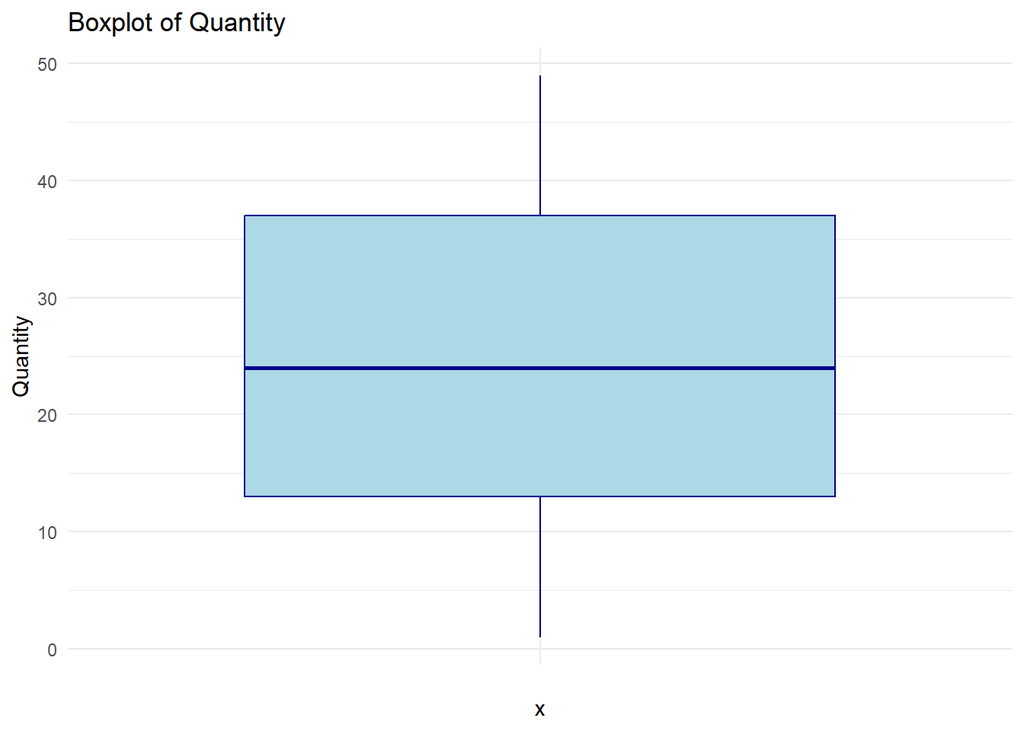

```r
# Boxplot for Quantity to visualize outliers

ggplot(data_reduced, aes(x = "", y = Quantity)) +
    geom_boxplot(fill = "lightblue", color = "darkblue") +
    labs(title = "Boxplot of Quantity", y = "Quantity") +
    theme_minimal()
```

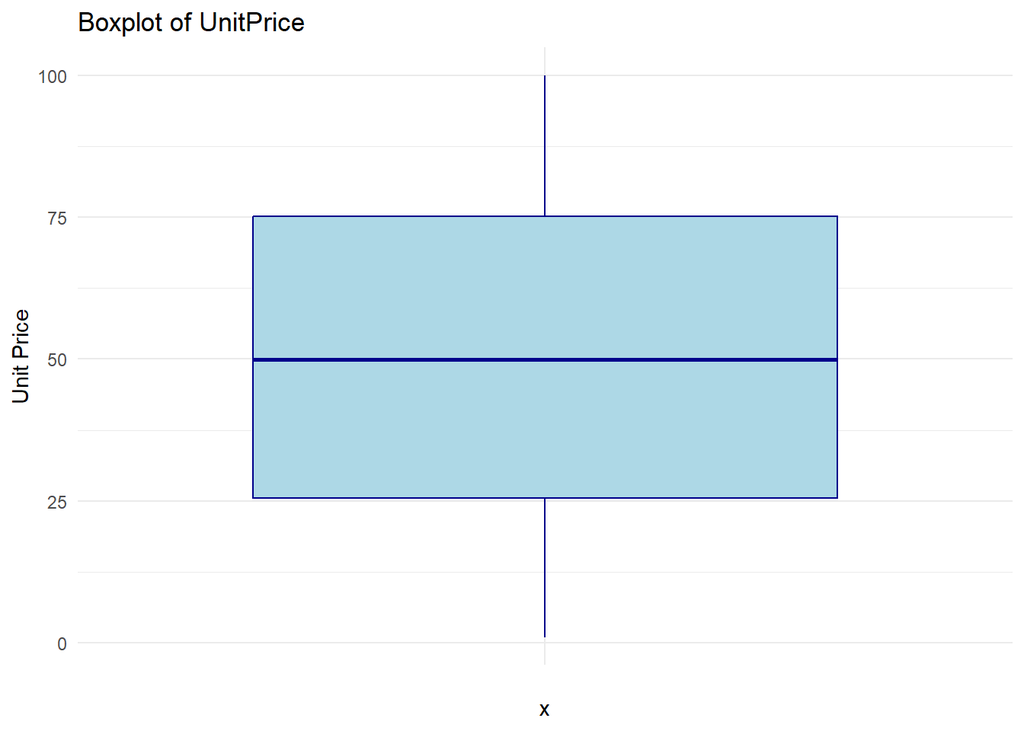

```r
# Boxplot for UnitPrice to visualize outliers

ggplot(data_reduced, aes(x = "", y = UnitPrice)) +
    geom_boxplot(fill = "lightblue", color = "darkblue") +
    labs(title = "Boxplot of UnitPrice", y = "Unit Price") +
    theme_minimal()
```

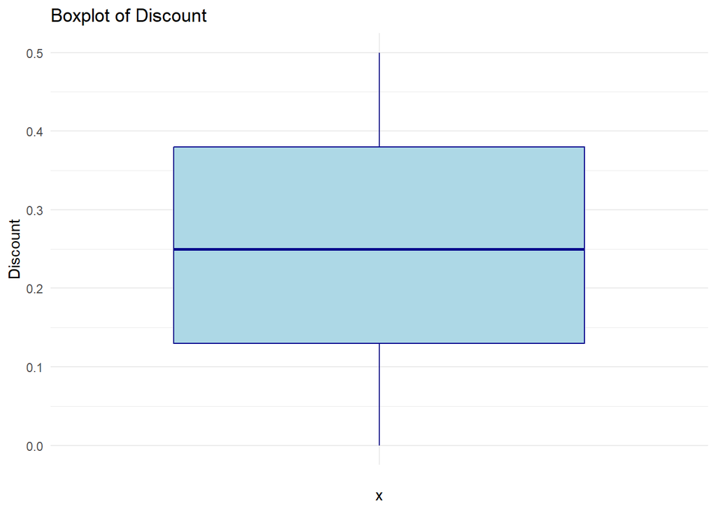

```r
# Boxplot for Discount to visualize outliers

ggplot(data_reduced, aes(x = "", y = Discount)) +
    geom_boxplot(fill = "lightblue", color = "darkblue") +
    labs(title = "Boxplot of Discount", y = "Discount") +
    theme_minimal()
```

## Detecting

```r
kd2_outliers <- function(column) {
  density <- density(column, na.rm = TRUE)
  threshold <- 0.01  # Define a threshold for low-density regions
  outlier_indices <- which(density(column)$y < threshold)
  return(length(outlier_indices))  # Return the count of outliers
}

outliers_quantity <- kd2_outliers(data_reduced$Quantity)
outliers_unit_price <- kd2_outliers(data_reduced$UnitPrice)
outliers_discount <- kd2_outliers(data_reduced$Discount)

cat("Outliers in Quantity:", outliers_quantity, "\n")
```

```
## Outliers in Quantity: 93
```

```r
cat("Outliers in Unit Price:", outliers_unit_price, "\n")
```

```
## Outliers in Unit Price: 287
```

```r
cat("Outliers in Discount:", outliers_discount, "\n")
```

```
## Outliers in Discount: 13
```

## 3.1 Removing

```r
remove_kd2_outliers <- function(df, column) {
  density <- density(df[[column]], na.rm = TRUE)
  threshold <- 0.01  # Define a threshold for low-density regions
  outlier_indices <- which(density$y < threshold)
  if (length(outlier_indices) > 0) {
    df <- df[-outlier_indices, ]
  }
  return(df)
}

cleaned_data <- data_reduced %>%
  remove_kd2_outliers("Quantity") %>%
  remove_kd2_outliers("UnitPrice") %>%
  remove_kd2_outliers("Discount")
```

Peak into the cleaned dataset after removing outliers

```r
str(cleaned_data)
```

```
## 'data.frame':    9611 obs. of  17 variables:
##  $ InvoiceNo        : int  336094 712551 469110 442709 571869 482306 256089 526185 664678 813135 ...
##  $ StockCode        : chr  "SKU_1420" "SKU_1564" "SKU_1075" "SKU_1224" ...
##  $ Description      : chr  "Wireless Mouse" "Desk Lamp" "Wall Clock" "Wall Clock" ...
##  $ Quantity         : int  22 42 12 3 7 7 45 8 46 36 ...
##  $ InvoiceDate      : chr  "29-08-2020 23:00" "21-06-2021 14:00" "08-03-2024 02:00" "28-10-2022 21:00" ...
##  $ UnitPrice        : num  71.9 40.2 56.2 69.6 48.5 ...
##  $ CustomerID       : int  79937 12179 37876 42557 90008 72445 48722 57101 86768 43145 ...
##  $ Country          : chr  "Sweden" "Germany" "United States" "Sweden" ...
##  $ Discount         : num  0.23 0.17 0.16 0.36 0.47 0.41 0.24 0.07 0.48 0.46 ...
##  $ PaymentMethod    : chr  "Credit Card" "Credit Card" "Bank Transfer" "Credit Card" ...
##  $ ShippingCost     : num  14.24 26.88 26 8.37 22.08 ...
##  $ Category         : chr  "Stationery" "Apparel" "Apparel" "Accessories" ...
##  $ SalesChannel     : chr  "Online" "In-store" "Online" "Online" ...
##  $ ReturnStatus     : chr  "Not Returned" "Not Returned" "Not Returned" "Not Returned" ...
##  $ ShipmentProvider : chr  "Royal Mail" "Royal Mail" "Royal Mail" "FedEx" ...
##  $ WarehouseLocation: chr  "Rome" "Rome" "Paris" "Berlin" ...
##  $ OrderPriority    : chr  "Medium" "Medium" "High" "Medium" ...
##  - attr(*, "na.action")= 'omit' Named int [1:3921] 5 50 63 72 104 145 148 168 174 177 ...
##   ..- attr(*, "names")= chr [1:3921] "5" "50" "63" "72" ...
```

```r
xkablesummary(cleaned_data)
```

Table: Statistics summary.

|  | InvoiceNo | StockCode | Description | Quantity | InvoiceDate | UnitPrice | CustomerID | Country | Discount | PaymentMethod | ShippingCost | Category | SalesChannel | ReturnStatus | ShipmentProvider | WarehouseLocation | OrderPriority |
| --- | --- | --- | --- | --- | --- | --- | --- | --- | --- | --- | --- | --- | --- | --- | --- | --- | --- |
| Min | Min. :100015 | Length:9611 | Length:9611 | Min. : 1.00 | Length:9611 | Min. : 1.01 | Min. :10003 | Length:9611 | Min. :0.0000 | Length:9611 | Min. : 5.00 | Length:9611 | Length:9611 | Length:9611 | Length:9611 | Length:9611 | Length:9611 |
| Q1 | 1st Qu.:327631 | Class :character | Class :character | 1st Qu.:13.00 | Class :character | 1st Qu.: 25.52 | 1st Qu.:32337 | Class :character | 1st Qu.:0.1300 | Class :character | 1st Qu.:11.06 | Class :character | Class :character | Class :character | Class :character | Class :character | Class :character |
| Median | Median :554318 | Mode :character | Mode :character | Median :24.00 | Mode :character | Median : 50.00 | Median :54951 | Mode :character | Median :0.2500 | Mode :character | Median :17.23 | Mode :character | Mode :character | Mode :character | Mode :character | Mode :character | Mode :character |
| Mean | Mean :551881 | NA | NA | Mean :24.74 | NA | Mean : 50.38 | Mean :54826 | NA | Mean :0.2507 | NA | Mean :17.36 | NA | NA | NA | NA | NA | NA |
| Q3 | 3rd Qu.:777169 | NA | NA | 3rd Qu.:37.00 | NA | 3rd Qu.: 75.16 | 3rd Qu.:77272 | NA | 3rd Qu.:0.3800 | NA | 3rd Qu.:23.62 | NA | NA | NA | NA | NA | NA |
| Max | Max. :999993 | NA | NA | Max. :49.00 | NA | Max. :100.00 | Max. :99980 | NA | Max. :0.5000 | NA | Max. :30.00 | NA | NA | NA | NA | NA | NA |

Converting variables into factors

```r
cleaned_data$InvoiceDate <- as.Date(cleaned_data$InvoiceDate, format = "%d-%m-%Y")
cleaned_data$Description = as.factor(cleaned_data$Description)
cleaned_data$StockCode = as.factor(cleaned_data$StockCode)
cleaned_data$Country = as.factor(cleaned_data$Country)
cleaned_data$PaymentMethod = as.factor(cleaned_data$PaymentMethod)
cleaned_data$Category = as.factor(cleaned_data$Category)
cleaned_data$ReturnStatus = as.factor(cleaned_data$ReturnStatus)
cleaned_data$SalesChannel = as.factor(cleaned_data$SalesChannel)
cleaned_data$ShipmentProvider = as.factor(cleaned_data$ShipmentProvider)
cleaned_data$OrderPriority = as.factor(cleaned_data$OrderPriority)
cleaned_data$WarehouseLocation = as.factor(cleaned_data$WarehouseLocation)
```

```r
str(cleaned_data)
```

```
## 'data.frame':    9611 obs. of  17 variables:
##  $ InvoiceNo        : int  336094 712551 469110 442709 571869 482306 256089 526185 664678 813135 ...
##  $ StockCode        : Factor w/ 1000 levels "SKU_1000","SKU_1001",..: 421 565 76 225 111 521 455 116 206 360 ...
##  $ Description      : Factor w/ 11 levels "Backpack","Blue Pen",..: 11 3 9 9 8 5 4 6 4 6 ...
##  $ Quantity         : int  22 42 12 3 7 7 45 8 46 36 ...
##  $ InvoiceDate      : Date, format: "2020-08-29" "2021-06-21" ...
##  $ UnitPrice        : num  71.9 40.2 56.2 69.6 48.5 ...
##  $ CustomerID       : int  79937 12179 37876 42557 90008 72445 48722 57101 86768 43145 ...
##  $ Country          : Factor w/ 12 levels "Australia","Belgium",..: 10 4 12 10 5 12 3 9 5 4 ...
##  $ Discount         : num  0.23 0.17 0.16 0.36 0.47 0.41 0.24 0.07 0.48 0.46 ...
##  $ PaymentMethod    : Factor w/ 3 levels "Bank Transfer",..: 2 2 1 2 3 3 1 3 2 3 ...
##  $ ShippingCost     : num  14.24 26.88 26 8.37 22.08 ...
##  $ Category         : Factor w/ 5 levels "Accessories",..: 5 2 2 1 2 5 4 5 1 2 ...
##  $ SalesChannel     : Factor w/ 2 levels "In-store","Online": 2 1 2 2 1 1 1 2 1 1 ...
##  $ ReturnStatus     : Factor w/ 2 levels "Not Returned",..: 1 1 1 1 1 1 1 1 1 1 ...
##  $ ShipmentProvider : Factor w/ 4 levels "DHL","FedEx",..: 3 3 3 2 4 3 4 4 3 4 ...
##  $ WarehouseLocation: Factor w/ 5 levels "Amsterdam","Berlin",..: 5 5 4 2 2 5 2 2 3 4 ...
##  $ OrderPriority    : Factor w/ 3 levels "High","Low","Medium": 3 3 1 3 1 2 3 1 3 1 ...
##  - attr(*, "na.action")= 'omit' Named int [1:3921] 5 50 63 72 104 145 148 168 174 177 ...
##   ..- attr(*, "names")= chr [1:3921] "5" "50" "63" "72" ...
```

# 4 Vizualisation

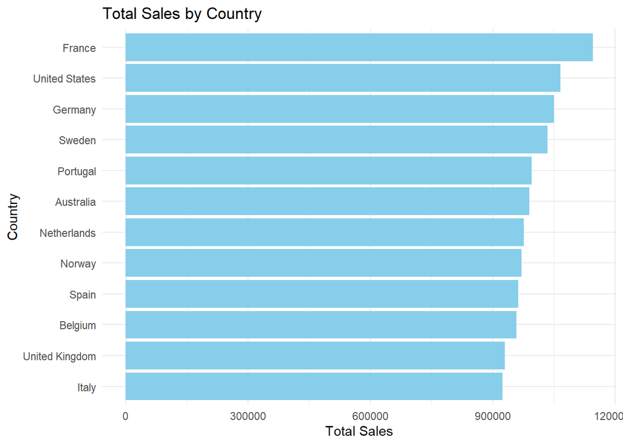

```r
sales_by_country <- cleaned_data %>%
  group_by(Country) %>%
  summarise(TotalSales = sum(UnitPrice * Quantity, na.rm = TRUE))

ggplot(sales_by_country, aes(x = reorder(Country, TotalSales), y = TotalSales)) +
  geom_bar(stat = "identity", fill = "skyblue") +
  coord_flip() +
  labs(
    title = "Total Sales by Country",
    x = "Country",
    y = "Total Sales"
  ) +
  theme_minimal()
```

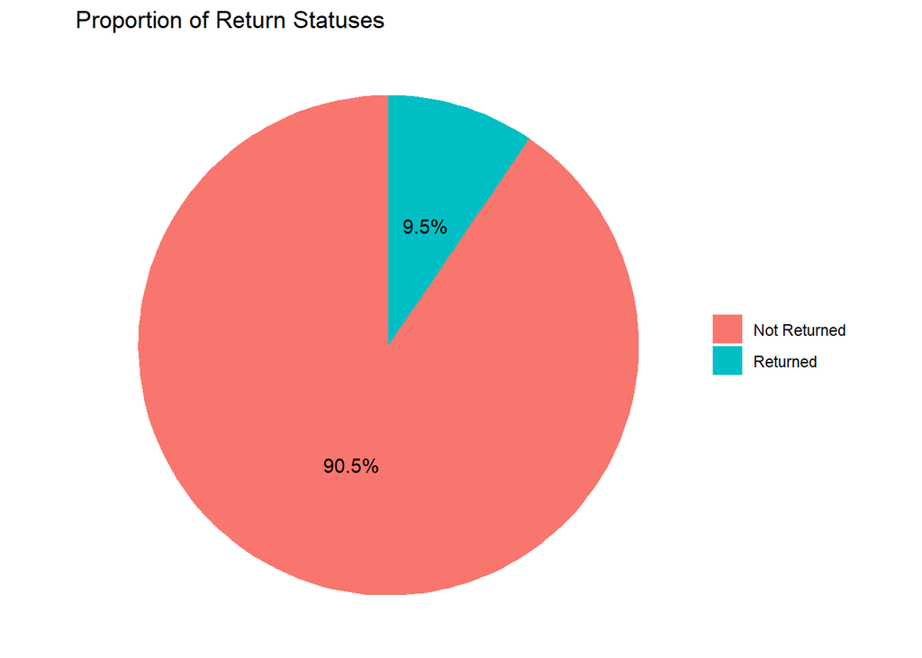

```r
return_status_counts <- cleaned_data %>%
  group_by(ReturnStatus) %>%
  summarise(Count = n()) %>%
  mutate(Percentage = (Count / sum(Count)) * 100)

ggplot(return_status_counts, aes(x = "", y = Count, fill = ReturnStatus)) +
  geom_bar(stat = "identity", width = 1) +
  coord_polar("y", start = 0) +
  geom_text(aes(label = paste0(round(Percentage, 1), "%")), position = position_stack(vjust = 0.5)) +
  labs(
    title = "Proportion of Return Statuses",
    x = NULL,
    y = NULL
  ) +
  theme_void() +
  theme(legend.title = element_blank())
```

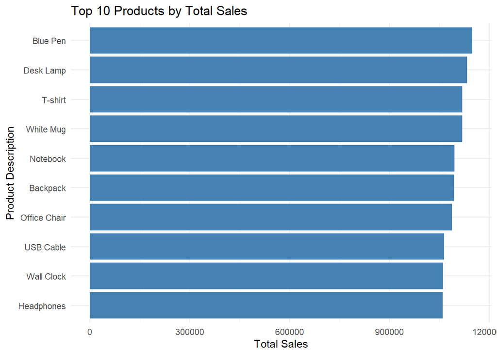

```r
top_products <- cleaned_data %>%
  group_by(Description) %>%
  summarise(TotalSales = sum(UnitPrice * Quantity, na.rm = TRUE)) %>%
  arrange(desc(TotalSales)) %>%
  slice(1:10)

ggplot(top_products, aes(x = reorder(Description, TotalSales), y = TotalSales)) +
  geom_bar(stat = "identity", fill = "steelblue") +
  coord_flip() +
  labs(
    title = "Top 10 Products by Total Sales",
    x = "Product Description",
    y = "Total Sales"
  ) +
  theme_minimal()
```

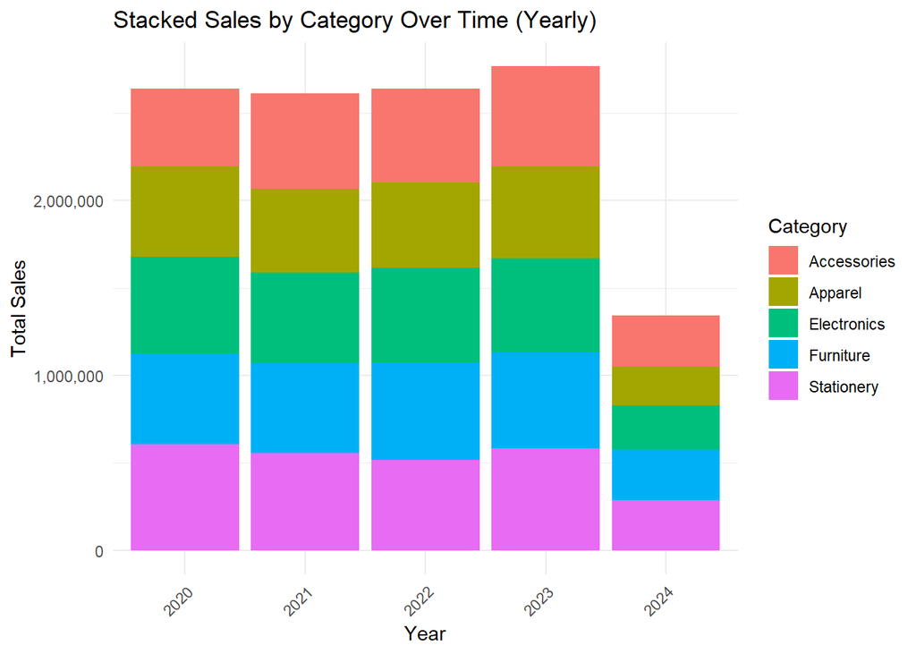

```r
cleaned_data <- cleaned_data %>%
  mutate(Year = format(InvoiceDate, "%Y"))

category_sales_yearly <- cleaned_data %>%
  group_by(Year, Category) %>%
  summarise(
    TotalSales = sum(UnitPrice * Quantity, na.rm = TRUE),
    .groups = "drop"
  )

category_sales_yearly$Year <- factor(category_sales_yearly$Year, levels = unique(category_sales_yearly$Year))

ggplot(category_sales_yearly, aes(x = Year, y = TotalSales, fill = Category)) +
  geom_bar(stat = "identity", position = "stack") +
  labs(
    title = "Stacked Sales by Category Over Time (Yearly)",
    x = "Year",
    y = "Total Sales",
    fill = "Category"
  ) +
  theme_minimal() +
  scale_y_continuous(labels = comma) +
  theme(axis.text.x = element_text(angle = 45, hjust = 1))
```

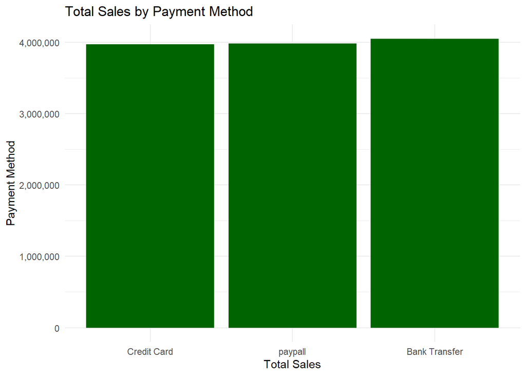

```r
sales_by_payment <- cleaned_data %>%
  group_by(PaymentMethod) %>%
  summarise(TotalSales = sum(UnitPrice * Quantity, na.rm = TRUE))

ggplot(sales_by_payment, aes(x = TotalSales, y = reorder(PaymentMethod, TotalSales))) +
  geom_bar(stat = "identity", fill = "darkgreen") +
  coord_flip() +
  labs(
    title = "Total Sales by Payment Method",
    x = "Payment Method",
    y = "Total Sales"
  ) +
  scale_x_continuous(labels = comma) +
  theme_minimal()
```

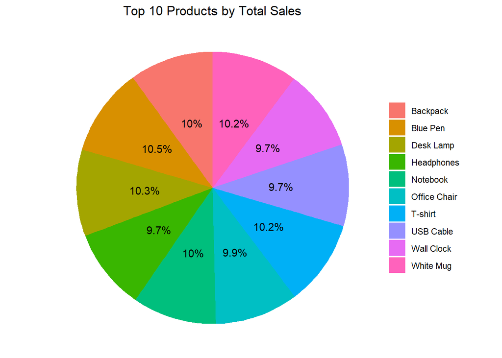

```r
top_products <- cleaned_data %>%
  group_by(Description) %>%
  summarise(TotalSales = sum(UnitPrice * Quantity, na.rm = TRUE)) %>%
  arrange(desc(TotalSales)) %>%
  slice_head(n = 10)

top_products <- top_products %>%
  mutate(Percentage = TotalSales / sum(TotalSales) * 100)

pie <- ggplot(top_products, aes(x = "", y = TotalSales, fill = Description)) +
  geom_bar(stat = "identity", width = 1) +
  coord_polar("y", start = 0) +
  geom_text(
    aes(label = paste0(round(Percentage, 1), "%")),
    position = position_stack(vjust = 0.5)
  ) +
  labs(
    title = "Top 10 Products by Total Sales",
    x = NULL,
    y = NULL
  ) +
  theme_void() +
  theme(
    legend.title = element_blank(),
    plot.title = element_text(hjust = 0.5)
  )

pie
```

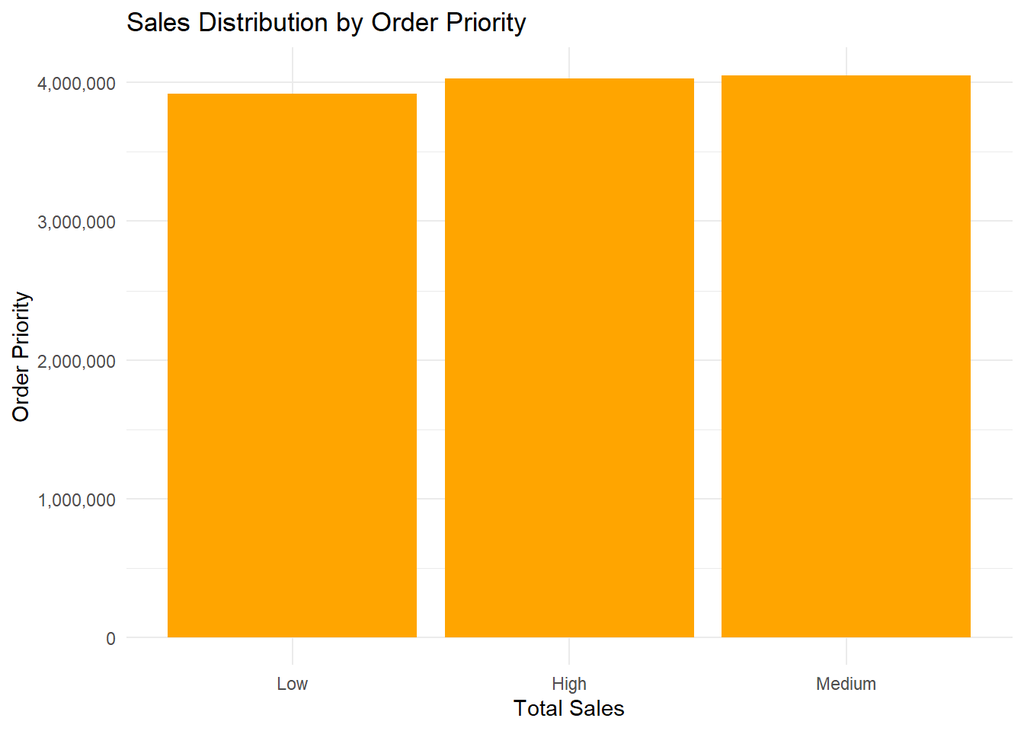

```r
sales_by_priority <- cleaned_data %>%
  group_by(OrderPriority) %>%
  summarise(TotalSales = sum(UnitPrice * Quantity, na.rm = TRUE))

ggplot(sales_by_priority, aes(x = TotalSales, y = reorder(OrderPriority, TotalSales))) +
  geom_bar(stat = "identity", fill = "orange") +
  coord_flip() +
  labs(
    title = "Sales Distribution by Order Priority",
    x = "Order Priority",
    y = "Total Sales"
  ) +
   scale_x_continuous(labels = comma) +
  theme_minimal()
```

```r
sales_by_category_return <- cleaned_data %>%
  group_by(Category, ReturnStatus) %>%
  summarise(TotalSales = sum(UnitPrice * Quantity, na.rm = TRUE))
```

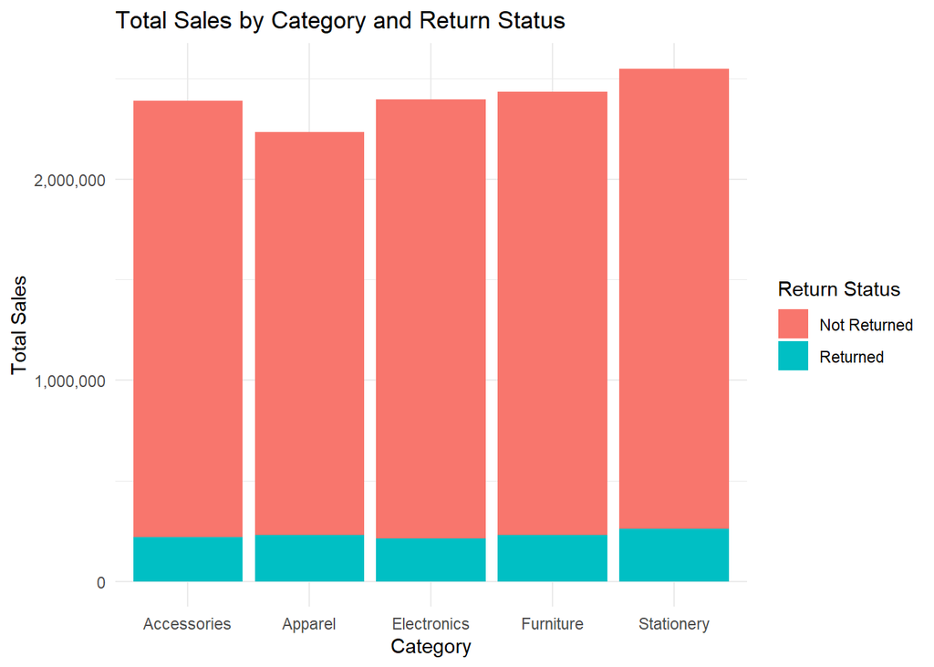

```r
ggplot(sales_by_category_return, aes(x = Category, y = TotalSales, fill = ReturnStatus)) +
  geom_bar(stat = "identity", position = "stack") +
  labs(
    title = "Total Sales by Category and Return Status",
    x = "Category",
    y = "Total Sales",
    fill = "Return Status"
  ) +
  scale_y_continuous(labels = comma) +
  theme_minimal()
```

# 5 Hypothesis Testing

## 5.1 Customer Segmentation

**Null Hypothesis (H₀)**: There is no significant association between the mode of payment and customer segmentation based on purchase frequency.

**Alternative Hypothesis (H₁)**: There is a significant association between the mode of payment and customer segmentation based on purchase frequency.

**Mode of Test:** Chi-square test for independence

```r
unique(cleaned_data$PaymentMethod)
```

```
## [1] Credit Card   Bank Transfer paypall
## Levels: Bank Transfer Credit Card paypall
```

```r
payment_segregation <- table(cleaned_data$PaymentMethod, cleaned_data$Category)
chisq_test <- chisq.test(payment_segregation)
print(chisq_test)
```

```
##
##  Pearson's Chi-squared test
##
## data:  payment_segregation
## X-squared = 1.4953, df = 8, p-value = 0.9928
```

## 5.2 Product Demand Hypothesis

**Null Hypothesis (H₀)**: Discounts have no significant impact on the average quantity purchased.

**Alternative Hypothesis (H₁)**: Discounts have a significant impact on the average quantity purchased.

**Mode of Test:** Independent samples t-test

```r
t_test <- t.test(Quantity ~ Discount > 0.1, data = cleaned_data)
print(t_test)
```

```
##
##  Welch Two Sample t-test
##
## data:  Quantity by Discount > 0.1
## t = 1.1254, df = 3140.7, p-value = 0.2605
## alternative hypothesis: true difference in means between group FALSE and group TRUE is not equal to 0
## 95 percent confidence interval:
##  -0.2945428  1.0882599
## sample estimates:
## mean in group FALSE  mean in group TRUE
##            25.05942            24.66256
```

The **p-value** is **greater** than **0.05**, hence we **fail to reject the null hypothesis** and this suggests that discount has no significant impact on average quantity purchased. The confidence interval further indicates that there’s no strong evidence for a significant difference in the average quantity purchased with and without a discount.

## 5.3 Logistics Optimization Hypothesis

**Null Hypothesis (H₀)**: The average shipping cost does not vary significantly between shipment providers.

**Alternative Hypothesis (H₁)**: The average shipping cost varies significantly between shipment providers.

**Mode of Test:** One-way ANOVA

```r
anova <- aov(ShippingCost ~ ShipmentProvider, data = data_reduced)
summary(anova)
```

```
##                    Df Sum Sq Mean Sq F value Pr(>F)
## ShipmentProvider    3     59   19.66   0.378  0.769
## Residuals        9996 519450   51.97
```

The **p-value** is **greater** than **0.05**, hence we **fail to reject the null hypothesis** and this suggests that there is no significant difference in the average shipping costs between the different shipment providers. And the low F-value is also suggesting that the variation between shipment providers is small compared to the variation within them. In conclusion, the type of shipment provider doesn’t have a strong impact on the cost of shipping.

## 5.4 Sales Channel Hypothesis:

**Null Hypothesis (H₀)**: There is no significant difference in sales volume between online and in-store channels.

**Alternative Hypothesis (H₁)**: Sales volume differs significantly between online and in-store channels.

**Mode of Test:** Independent samples t-test

```r
t_test2 <- t.test(Quantity ~ SalesChannel, data = data_reduced)
print(t_test2)
```

```
##
##  Welch Two Sample t-test
##
## data:  Quantity by SalesChannel
## t = 0.061104, df = 9969.8, p-value = 0.9513
## alternative hypothesis: true difference in means between group In-store and group Online is not equal to 0
## 95 percent confidence interval:
##  -0.5372493  0.5718213
## sample estimates:
## mean in group In-store   mean in group Online
##               24.78720               24.76992
```

The **p-value** is **greater** than **0.05**, which means we **fail to reject null hypothesis** and this suggests that there is a statistically no significant difference in sales volume between online and in-store channels. The confidence interval is further supporting the conclusion that there is no significant difference in sales volume between the two channels.

## 5.5 Return Patterns Hypothesis:

**Null Hypothesis (H₀)**: Return rates are not significantly higher for any particular product category.

**Alternative Hypothesis (H₁)**: Return rates are significantly higher for certain product categories.

**Mode of Test:** Chi-square test for independence

```r
return_category <- table(data_reduced$ReturnStatus, data_reduced$Category)
chisq_test2 <- chisq.test(return_category)
print(chisq_test2)
```

```
##
##  Pearson's Chi-squared test
##
## data:  return_category
## X-squared = 1.8935, df = 4, p-value = 0.7553
```

The **p-value** is **greater** than **0.05**, hence we **fail to reject the null hypothesis** and this suggests that there is no significant difference in return rates between the product categories. Based on the result we do not have enough evidence to say that there is an association between the 2 parameters.